# WISC & Data Science Club RNA-seq analysis workshop, Fall 2020

06/11/2020

## Presenters

Huiwen Zheng (AIBN, UQ)

Atefeh Taherian Fard (AIBN, UQ)

## Resources and data files

You can access and download the dataset used in the workshop through GEO website with accession number: GSE65267

**Note**: Please download the following files and place them in your`./data` directory.

## Overview

- Introducing R basics
- Loading gene expression data into the R environment
- Identifying and filtering lowly expressed genes
- Differential expression analysis
- Normalisation
- Principal Component Analysis (PCA)
- Visualisation
- Pathway over-representation analysis
- Resourses for analysing both bulk and single-cell RNA-sequencing data

## Introduction and data import

The dataset used in this tutorial contains the RNA-sequence data of mouse kidney before and at various time points (1, 2, 3, 7 & 14 days) after intraperitoneal treatment with folic acid to investigate kidney function-loss.

There are many steps involved in analysing RNA-seq experiment which begins with sequencing reads. The reads are aligned to a reference genome; then the number of reads mapped to each gene is counted, resulting in a table of counts, which is what we use to perform statistical analyses on in R today.

*Set up an RStudio project specifying the directory where you have saved the `/data` directory*

First, let’s load all the packages we need to anlyse the data.

```r
#install.packages(c("scales","pheatmap"))
#install.packages("BiocManager") #install and manage packages in Bioconductor
#BiocManager::install(c("DESeq2","org.Mm.eg.db", "vsn"))

library(DESeq2)
library(org.Mm.eg.db)
library(RColorBrewer)
library(clusterProfiler)
library(pheatmap)
```

### Dataset-Mouse chronic kidney disease

The data used in this tutorial comes from the following paper [RNA Sequencing Identifies Novel Translational Biomarkers of Kidney Fibrosis](https://www.ncbi.nlm.nih.gov/pubmed/26449608)

### Loading the count data

```r
#Load the data into R
kidney.dat <- read.csv("Count_matrix.csv", row.names = 1, stringsAsFactors = F)

#Load the sample information (metadata) into R
metadata <- read.csv("Metadata.csv", row.names = 1, stringsAsFactors = F)

rownames(metadata) <- colnames(kidney.dat) # Make sure the columns in the dataset are matching to the row names in the metadata file

# Examine the count matrix
head(kidney.dat)
```

```
##       Normalrep1 Normalrep2 Normalrep3 FA1dayrep1 FA1dayrep2 FA1dayrep3
## Gnai3        456        606        451       2291       1729       2267
## Pbsn           0          0          0          0          0          0
## Cdc45          8         32          0         38         29         46
## H19            0          0          0         10          5          0
## Scml2         26          1          0          0         44          6
## Apoh          27         56         16         30          4         51
##       FA2dayrep1 FA2dayrep2 FA2dayrep3 FA3dayrep1 FA3dayrep2 FA3dayrep3
## Gnai3       2069        271        736        972       1090       1337
## Pbsn           0          0          0          0          0          0
## Cdc45        198          4        126         59          6         70
## H19            0          0          2          0          0          0
## Scml2          2          0          5         13          3          0
## Apoh          11          3          1          1         29          8
##       FA7dayrep1 FA7dayrep2 FA7dayrep3 FA14dayrep1 FA14dayrep2 FA14dayrep3
## Gnai3       1068       1012       1067         609         552         606
## Pbsn           0          0          0           0           0           0
## Cdc45         11          7         50           9          14          32
## H19            0          0          0           0           0           0
## Scml2          8         96          1           6           3           1
## Apoh          34          7         35          26           2          56
```

```r
#str(kidney.dat)

# Examine the metadata file
head(metadata)
```

```
##              sample_id   group
## Normalrep1 Controlrep1 Control
## Normalrep2 Controlrep2 Control
## Normalrep3 Controlrep3 Control
## FA1dayrep1  FA1dayrep1    Day1
## FA1dayrep2  FA1dayrep2    Day1
## FA1dayrep3  FA1dayrep3    Day1
```

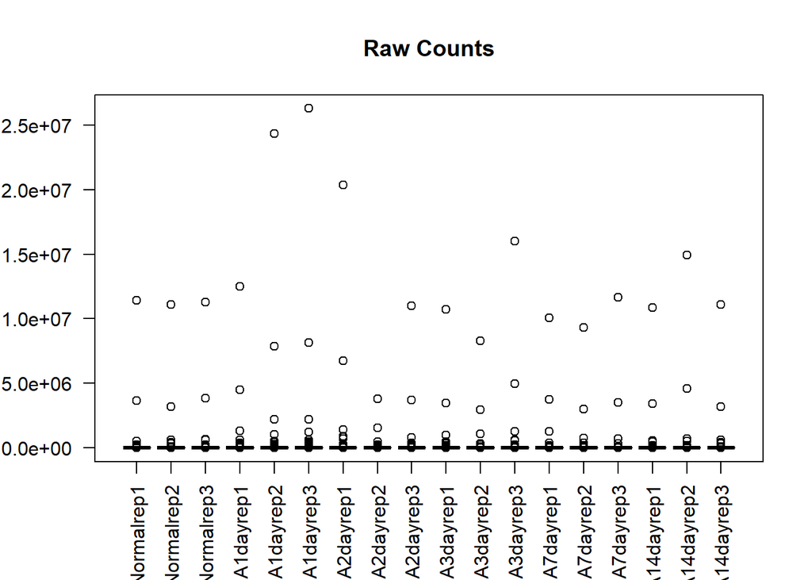

```r
boxplot(kidney.dat, main = "Raw Counts", las = 2) # A quick look at the data
```

```r
#use par() to specific set/increase the plot's window par(mar = c (10,10,4,2)+0.1)

# Create DESeqDataSet
dds <- DESeqDataSetFromMatrix(countData = kidney.dat,
                              colData = metadata,
                              design = ~ group)
dds
```

```
## class: DESeqDataSet
## dim: 32890 18
## metadata(1): version
## assays(1): counts
## rownames(32890): Gnai3 Pbsn ... Vmn1r-ps147 Methig1
## rowData names(0):
## colnames(18): Normalrep1 Normalrep2 ... FA14dayrep2 FA14dayrep3
## colData names(2): sample_id group
```

### Filtering out low expressed genes

```r
keep <- rowSums(counts(dds)) >= round(0.1*length(kidney.dat))
length(keep) # Numbers of samples that have more than 10 genes expressed
```

```
## [1] 32890
```

```r
dds <- dds[keep,]
length(dds)
```

```
## [1] 23888
```

### Differential gene expression analysis

The standard differential expression analysis steps are wrapped into a single function. DESeq.Results tables are generated using the function results, which extracts a results table with log2 fold changes, p-values and adjusted p-values.

If we don’t specify which group we want to compare, the comparsion will be based on the alphabatic order of the levels AND the foldchange in the result table will be the last level of this variable over the reference level.

*Note:* You can change the reference level using the relevel() function.

```r
# So let's see what are the levels in the group object
factor(metadata$group)
```

```
##  [1] Control Control Control Day1    Day1    Day1    Day2    Day2    Day2
## [10] Day3    Day3    Day3    Day7    Day7    Day7    Day14   Day14   Day14
## Levels: Control Day1 Day14 Day2 Day3 Day7
```

```r
dds <- DESeq(dds)
# Results tables are generated using the function results()
res0 <- results(dds)
res0 # Comparing between Day7 vs Control
```

```
## log2 fold change (MLE): group Day7 vs Control
## Wald test p-value: group Day7 vs Control
## DataFrame with 23888 rows and 6 columns
##               baseMean log2FoldChange     lfcSE       stat    pvalue      padj
##              <numeric>      <numeric> <numeric>  <numeric> <numeric> <numeric>
## Gnai3       975.313648       0.468554  0.334372   1.401296  0.161126  0.568047
## Cdc45        33.613512       0.391623  1.018641   0.384456  0.700640  0.925215
## H19           0.900697      -0.598894  5.267649  -0.113693  0.909481        NA
## Scml2        11.052510       1.362821  1.751359   0.778151  0.436480  0.815071
## Apoh         22.536815      -0.895314  1.127877  -0.793804  0.427309  0.810120
## ...                ...            ...       ...        ...       ...       ...
## Obox3-ps7     0.120301      -1.560512  5.267649 -0.2962445  0.767043        NA
## Vmn1r-ps151   1.575208       2.464159  2.600601  0.9475346  0.343366        NA
## Gm20648       6.469432       0.505671  1.256271  0.4025172  0.687303  0.921740
## Gm22395      10.750088       0.339989  0.818216  0.4155241  0.677758  0.920279
## Methig1       0.104150       0.362957  5.267649  0.0689031  0.945067        NA
```

In the result table, the lfcSE gives the standard error of the log2FoldChange. For the Wald test, stat is the Wald statistic: the log2FoldChange divided by lfcSE, which is compared to a standard Normal distribution to generate a two-tailed pvalue.

If you want to choose a specific pairwise comparison, you can use `name` or `contrast` function to make your own contrast list.

```r
#res <- results(dds, name="group_Day1_vs_Control")
res <- results(dds, contrast=c("group","Day1","Control"))
res
```

```
## log2 fold change (MLE): group Day1 vs Control
## Wald test p-value: group Day1 vs Control
## DataFrame with 23888 rows and 6 columns
##               baseMean log2FoldChange     lfcSE      stat      pvalue
##              <numeric>      <numeric> <numeric> <numeric>   <numeric>
## Gnai3       975.313648       1.186921  0.333867  3.555074 0.000377873
## Cdc45        33.613512       0.807978  1.012599  0.797925 0.424914159
## H19           0.900697       4.211425  5.144809  0.818578 0.413027500
## Scml2        11.052510      -0.448536  1.761204 -0.254676 0.798973645
## Apoh         22.536815      -1.041026  1.126486 -0.924135 0.355415847
## ...                ...            ...       ...       ...         ...
## Obox3-ps7     0.120301      -1.964850  5.267649 -0.373003    0.709146
## Vmn1r-ps151   1.575208       1.099577  2.646194  0.415531    0.677753
## Gm20648       6.469432       0.769550  1.244983  0.618121    0.536496
## Gm22395      10.750088      -0.115948  0.820446 -0.141324    0.887614
## Methig1       0.104150       0.000000  5.267649  0.000000    1.000000
##                   padj
##              <numeric>
## Gnai3       0.00735263
## Cdc45       0.71113503
## H19                 NA
## Scml2       0.92269682
## Apoh        0.65510569
## ...                ...
## Obox3-ps7           NA
## Vmn1r-ps151         NA
## Gm20648       0.787520
## Gm22395       0.961634
## Methig1             NA
```

### P-values and adjusted p-values

Note that the results function automatically performs independent filtering based on the mean of normalised counts for each gene, optimising the number of genes with adjusted p-value below a given FDR cutoff, `alpha` (The default is 0.1).

How many adjusted p-values are smaller than 0.05?

```r
res05 <- results(dds, alpha=0.05)

# Counting the number of significantly expreseed genes with alpha at 0.05
sum(res05$padj < 0.05, na.rm=TRUE)
```

```
## [1] 410
```

### Further exploring DE genes

We make a volcano plot based on the DE analysis results between **Day1** & **Control**, p.adj values and log2FoldChanges. Genes that have p.adj<0.05 are colored in red.

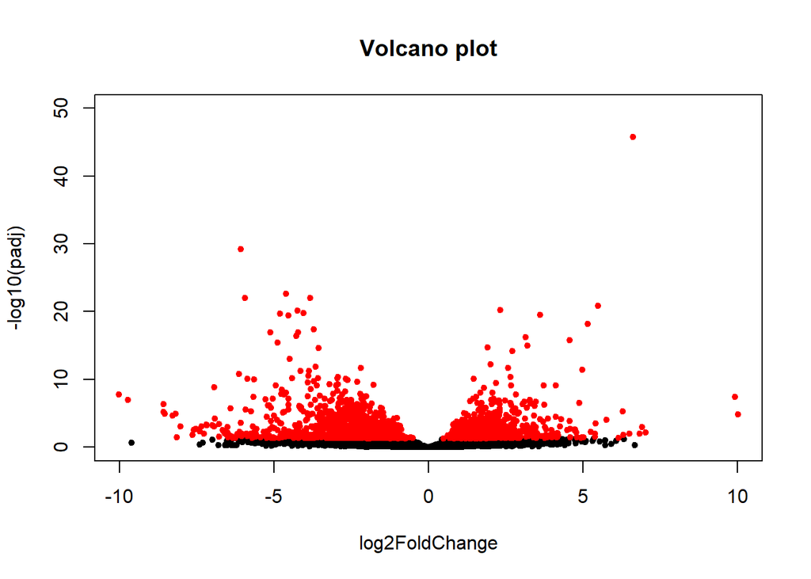

```r
# Make a basic volcano plot
with(res, plot(log2FoldChange, -log10(padj), pch=20, main="Volcano plot", xlim=c(-10,10), ylim=c(0,50)))

# Add colored points: red if padj<0.05
with(subset(res, padj<.05 ), points(log2FoldChange, -log10(padj), pch=20, col="red"))
```

### Data transformation for clustering and visualisation purposes

We perform differential expression analysis on raw counts; this is because data normalisation in the DESeq2 model happens internally, correcting for library size. However for other downstream analyses - e.g. for visualisation or clustering - it is useful to work with the transformed/scaled versions of the count data.

There are two data transformation methods for count data in Deseq2: **variance stabilizing transformations (VST)** and **regularized logarithm (rlog)** .

Here we use to *VST* for transforming the data.

```r
vsd <- vst(dds)
#rld <- rlog(dds)

head(assay(vsd),5) # Have a look at the normalised gene expression
```

```
##       Normalrep1 Normalrep2 Normalrep3 FA1dayrep1 FA1dayrep2 FA1dayrep3
## Gnai3   9.458240   9.440468   9.641788  11.365023  10.010232  10.215724
## Cdc45   5.380624   6.092646   4.294184   6.273585   5.580073   5.798644
## H19     4.294184   4.294184   4.294184   5.366294   4.842662   4.294184
## Scml2   6.165443   4.632325   4.294184   4.294184   5.853963   4.858875
## Apoh    6.196713   6.582772   5.901189   6.078281   4.785342   5.871341
##       FA2dayrep1 FA2dayrep2 FA2dayrep3 FA3dayrep1 FA3dayrep2 FA3dayrep3
## Gnai3  10.140889  10.333544   9.597750   9.788871  10.122428   9.893841
## Cdc45   7.137816   5.644229   7.347769   6.428061   5.077156   6.363513
## H19     4.294184   4.294184   4.752907   4.294184   4.294184   4.294184
## Scml2   4.627799   4.294184   5.015027   5.364922   4.851182   4.294184
## Apoh    5.068980   5.473386   4.619230   4.597457   5.945165   5.046714
##       FA7dayrep1 FA7dayrep2 FA7dayrep3 FA14dayrep1 FA14dayrep2 FA14dayrep3
## Gnai3   9.926126   9.982300   9.981446    9.524511    9.293962    9.440468
## Cdc45   5.284856   5.127394   6.321500    5.318468    5.516298    6.092646
## H19     4.294184   4.294184   4.294184    4.294184    4.294184    4.294184
## Scml2   5.143415   7.005745   4.604470    5.136183    4.873088    4.632325
## Apoh    5.973824   5.127394   6.027294    5.975206    4.767904    6.582772
```

### The effect of normalisation

The figure below plots the standard deviation of the transformed data, across samples, against the mean, using vst.

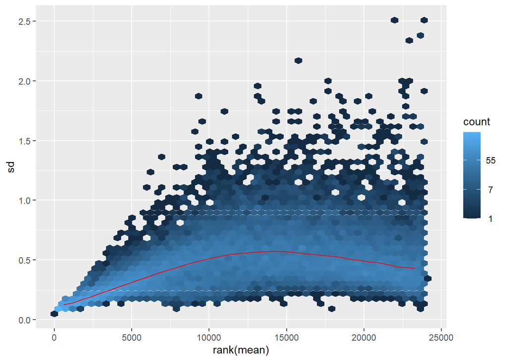

```r
library("vsn")
meanSdPlot(assay(vsd))
```

```r
#meanSdPlot(assay(rld))
```

The figure below shows the expression distribution of samples before and after normalisation using **VST**. The data is normalised by `Median of ratios method`.

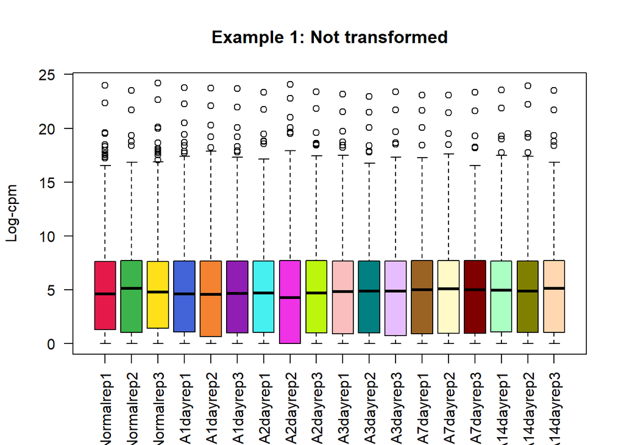

```r
library(RColorBrewer)
col_vector<-c('#e6194b', '#3cb44b', '#ffe119', '#4363d8', '#f58231', '#911eb4', '#46f0f0', '#f032e6', '#bcf60c', '#fabebe', '#008080', '#e6beff', '#9a6324', '#fffac8', '#800000', '#aaffc3', '#808000', '#ffd8b1')

# this gives log2(n + 1) transformation only
ntd <- normTransform(dds)
boxplot(assay(ntd), las=2,col=col_vector)
title(main="Example 1: Not transformed",ylab="Log-cpm")
```

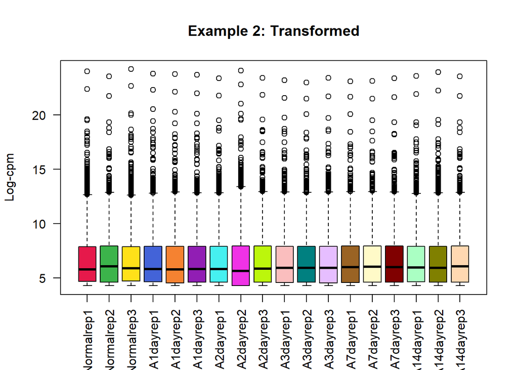

```r
boxplot(assay(vsd), las=2,col=col_vector)
title(main="Example 2: Transformed",ylab="Log-cpm")
```

### Dimensional Reduction visualisation

**Principal component plot** is used for visualising the overall effect of experimental covariates.

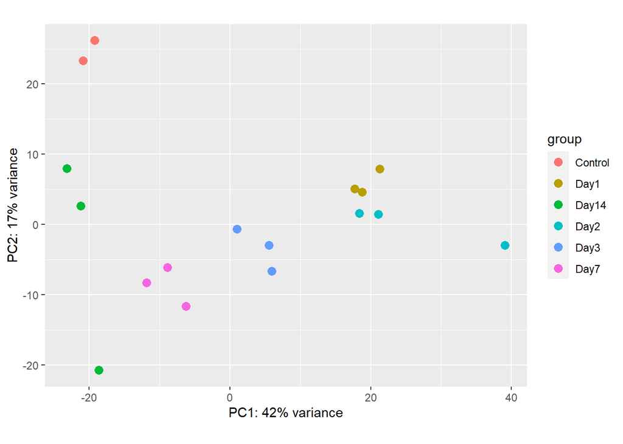

```r
plotPCA(vsd, intgroup = "group")
```

```r
#plotPCA(rld, intgroup = "group")
```

To explore the significantly expressed genes, it is often informative to plot a heatmap. Below we show how to create a heatmap of DE genes in all groups.

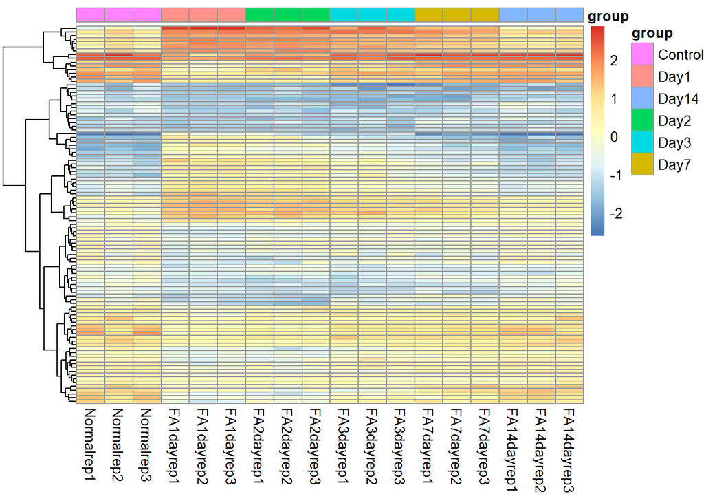

```r
# First we order the genes based on their p.adj values and identify the top 100 for plotting the heatmap

resOrdered <- res[order(res$padj),]# Order the dataframe based on the adjusted p-values
df <- assay(vsd)[rownames(assay(vsd)) %in% resOrdered@rownames[1:100],] # Select the top 100 genes
df <- scale(df) # Scale the data before plotting

anno <- as.data.frame(colData(dds)[,"group"])
rownames(anno) <- colnames(dds)
colnames(anno) <- "group"

pheatmap(df, cluster_rows= TRUE, show_rownames=FALSE,
         cluster_cols=FALSE, annotation_col = anno)
```

### Pathway over-representation anaysis

Over-representation methods compare sets of genes annotated to pathways to a list of those genes that are significantly deferentially expressed between two phenotypes. Here we use [Gene Ontology Database](http://geneontology.org/).

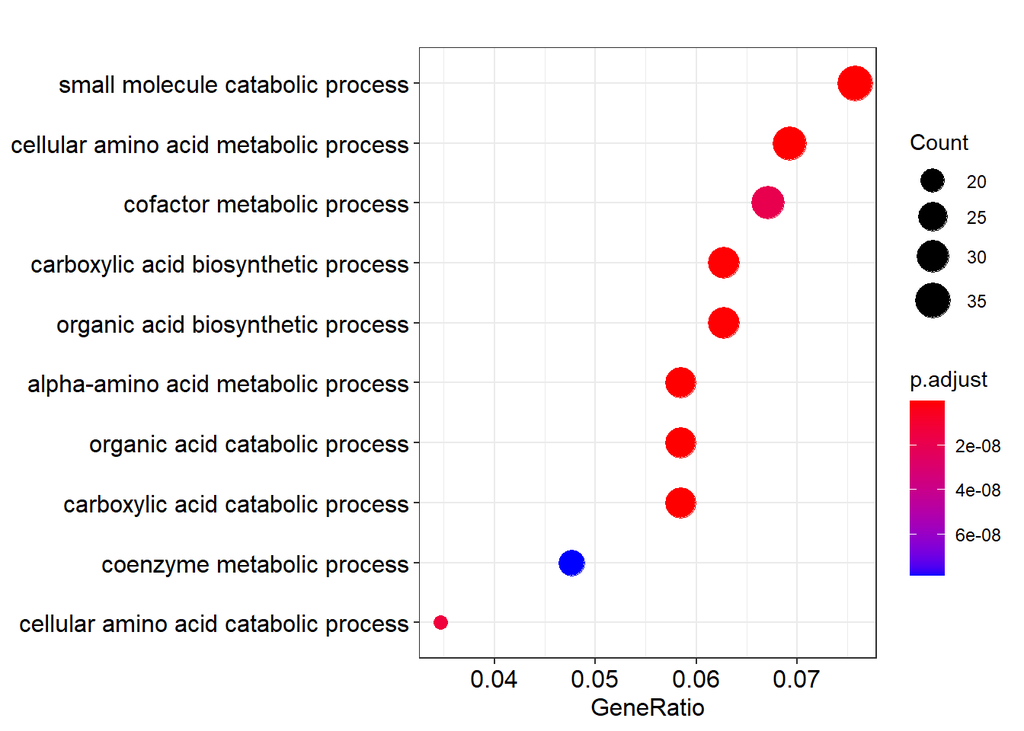

```r
# We extract top 500 genes for over-representation analysis
Genelist <- resOrdered@rownames[1:500]

# We use BP -- represents Biological Processes for downstream analysis in GO database
orgo <- enrichGO(Genelist, OrgDb = org.Mm.eg.db, ont='BP',pvalueCutoff = 0.05, qvalueCutoff = 0.2,keyType = 'SYMBOL')

dotplot(orgo,showCategory=10) # Dotplot for the top 10 GO terms
```

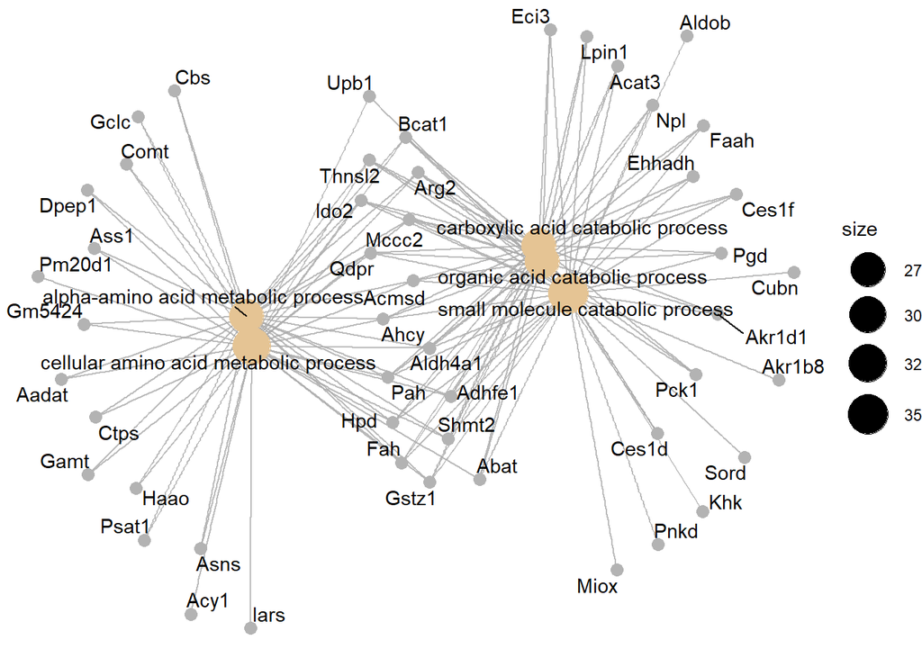

```r
cnetplot(orgo) # Network plot of significant terms
```

### References and other resources

R resources: * [Bioconductor workflows](https://www.bioconductor.org/packages/release/BiocViews.html#___Workflow) * [Introduction to R, Rstudio, Git and more](https://software-carpentry.org/lessons/)

Bulk RNA-seq analysis: * [DESeq2](https://bioconductor.org/packages/release/bioc/vignettes/DESeq2/inst/doc/DESeq2.html) * [RNAseq123](https://www.bioconductor.org/packages/release/workflows/html/RNAseq123.html)

Single-cell RNA-seq analysis: * [Seurat](https://satijalab.org/seurat/) * [Orchestrating Single-Cell Analysis with Bioconductor](http://bioconductor.org/books/release/OSCA/) * [ClusterProfiler](https://yulab-smu.github.io/clusterProfiler-book/)